# AMED3002 Module 1 Report

Elwood Fong

2025-02-21

### 1 Contents

- Abstract
- Introduction
- Results
- Discussion
- Conclusion

### 2 Abstract

For the living subjects in the community of Framingham, Massachusetts: - In early stages of life, men do have a higher systolic blood pressure. - In later stages of life, women have a higher systolic blood pressure than men.

### 3 Introduction

This report’s intention is to determine the answer to the following question:

> Do men have higher blood pressure than women?

### 4 Results

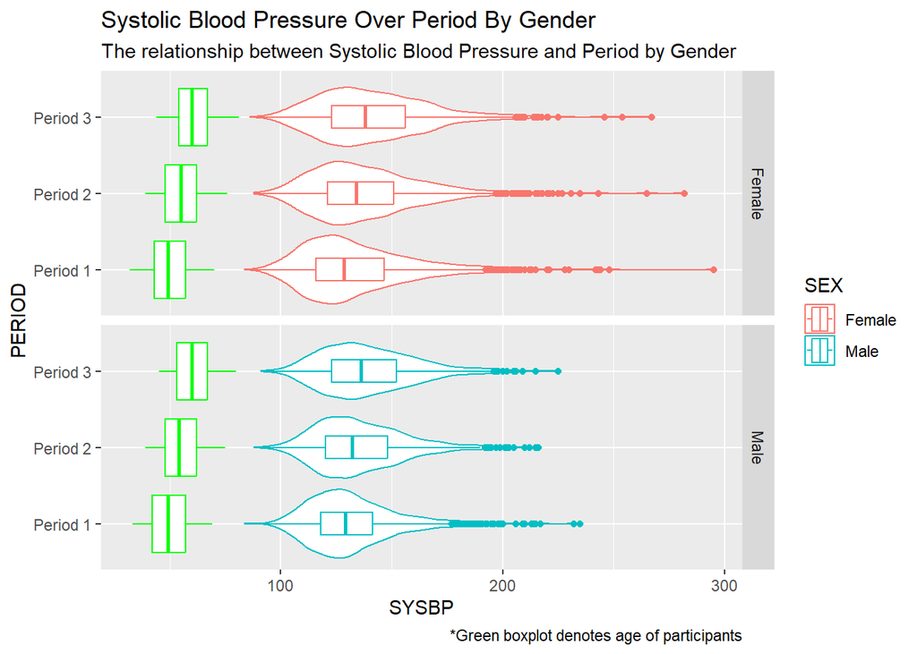

Figure 1: A violin and boxplot showing the systolic blood pressure of the participants over each period by gender.

### 5 Discussion

The age range for the participants of each period are very similar for each sex. Additionally, the data collected form Framingham Heart Study can be considered reliable for the living subjects in the community of Framingham, Massachusetts due to the large sample size. But there is not mention of the ethnicities nor environmental factors of each participant, which may be a factor in answering the question.

### 6 Conclusion

In conclusion, the answer to the question “Do men have higher blood pressure than women?” is as follows for the living subjects in the community of Framingham, Massachusetts: - In early stages of life, men do have a higher systolic blood pressure. - In later stages of life, women have a higher systolic blood pressure than men.